Connected to m1t (Python 3.12.7)

# US Per-State Public Education Value-for-Money Comparison

Date created: 20240313

```python
import pandas as pd
import numpy as np
from sklearn.model_selection import train_test_split
from sklearn.metrics import accuracy_score
import io
import re

pd.options.display.max_rows = 200
pd.options.display.max_columns = 50
```

src: [Which State Has The Best Test Scores? Analyzing Standardized Testing Trends – Forbes Advisor](https://www.forbes.com/advisor/education/student-resources/which-states-have-the-highest-standardized-test-scores/)

```python
data1 = """Rank	State	Grade 4 Math % at/above Proficient	Grade 4 Reading % at/above Proficient	Grade 8 Math % at/above Proficient	Grade 8 Reading % at/above Proficient	Average SAT Score	Average ACT Score	Average MCAT Score
1	Massachusetts	42.90%	42.61%	35.06%	39.80%	1,112	26	515
5	Connecticut	37.01%	34.62%	29.95%	34.77%	1,007	26	514
40	District of Columbia	24.27%	26.49%	16.45%	22.16%	969	26	513
23	California	30.08%	30.96%	22.97%	29.88%	1,083	26	514
22	New York	28.42%	29.65%	28.39%	32.30%	1,039	25	513
4	New Hampshire	39.96%	37.02%	28.96%	32.82%	1,035	25	516
25	Maine	31.94%	29.19%	24.37%	29.29%	1,080	25	514
42	Delaware	25.66%	25.29%	18.29%	23.84%	958	25	513
7	Virginia	37.72%	31.82%	31.21%	30.98%	1,113	25	513
8	Colorado	36.40%	37.59%	27.82%	34.16%	996	25	514
15	Washington	34.97%	33.72%	27.81%	31.78%	1,081	25	513
19	Illinois	37.52%	33.30%	26.52%	32.37%	970	25	512
21	Rhode Island	33.65%	33.81%	23.65%	31.32%	958	25	515
26	Maryland	31.09%	30.64%	24.67%	32.78%	1,008	25	513
3	New Jersey	39.42%	38.02%	33.14%	41.58%	1,066	24	514
20	Michigan	32.26%	28.29%	25.43%	28.15%	967	24	511
14	Pennsylvania	40.24%	33.98%	27.41%	30.57%	1,078	24	513
10	Vermont	34.43%	33.64%	26.92%	34.46%	1,099	24	514
27	Idaho	36.33%	31.91%	32.43%	32.12%	970	23	511
18	Indiana	39.57%	32.85%	30.11%	30.62%	971	23	513
34	Georgia	33.95%	31.54%	23.71%	30.60%	1,054	21	509
11	South Dakota	40.28%	32.40%	32.23%	31.12%	1,208	21	510
36	Oregon	28.61%	27.99%	22.03%	27.79%	1,125	21	512
12	Minnesota	40.70%	32.17%	31.53%	29.66%	1,201	21	511
13	Iowa	40.42%	33.03%	28.08%	28.81%	1,208	21	512
49	West Virginia	22.84%	22.28%	15.09%	21.66%	923	20	508
43	Alaska	27.70%	24.42%	23.27%	25.97%	1,082	20	510
50	New Mexico	19.12%	20.97%	12.69%	18.43%	901	20	507
2	Utah	42.08%	36.83%	34.50%	35.66%	1,239	20	514
31	Missouri	34.17%	30.29%	23.91%	28.48%	1,191	20	511
28	North Dakota	40.35%	30.97%	28.20%	27.07%	1,287	20	506
6	Wisconsin	42.90%	32.60%	33.22%	32.39%	1,236	19	512
32	Kansas	34.87%	30.55%	23.22%	25.81%	1,245	19	510
39	Texas	38.13%	29.94%	23.77%	23.22%	978	19	512
9	Nebraska	43.20%	34.01%	30.96%	28.82%	1,252	19	512
17	Ohio	39.99%	34.51%	29.02%	33.13%	1,044	19	512
16	Wyoming	44.14%	38.34%	31.38%	29.74%	1,200	19	510
30	Florida	40.80%	38.99%	22.95%	29.36%	966	19	511
24	Montana	38.03%	33.74%	28.54%	29.11%	1,193	19	510
41	South Carolina	33.96%	32.45%	22.02%	26.56%	1,028	19	510
37	Kentucky	32.59%	31.07%	21.50%	29.02%	1,208	19	508
44	Arkansas	27.94%	29.66%	18.93%	25.79%	1,192	19	507
33	North Carolina	35.40%	32.32%	25.38%	25.69%	1,127	19	512
35	Tennessee	36.05%	30.17%	24.78%	28.04%	1,191	18	510
45	Louisiana	27.16%	28.29%	18.89%	26.86%	1,194	18	508
48	Alabama	27.17%	28.26%	18.69%	22.03%	1,161	18	509
29	Hawaii	37.00%	35.22%	22.21%	30.67%	1,114	18	512
51	Oklahoma	26.83%	24.02%	15.93%	21.28%	953	18	509
38	Arizona	32.31%	31.37%	23.80%	28.18%	1,183	18	511
47	Mississippi	32.07%	30.64%	17.75%	21.98%	1,184	18	507
46	Nevada	28.39%	26.92%	20.82%	28.80%	1,166	17	509
"""
```

src: [Per Pupil Spending by State 2024](https://worldpopulationreview.com/state-rankings/per-pupil-spending-by-state)

```python
data2 = """State	Public Spending Per K-12 Student	Public Funding Per K-12 Student	Cost Of Living Index	K-12 Spending As Perc Taxpayer Income	Teachers As A Percent Of Staff Salaries	Public Education Average Post Secondary
Alabama	$10,108	$11,377	88.80	3.42%	56.9%	$21,760
Alaska	$18,392	$19,553	124.40	5.2%	46.1%	$27,266
Arizona	$8,770	$10,392	107.20	2.88%	46.5%	$25,166
Arkansas	$10,414	$11,736	90.30	3.79%	48.6%	$26,246
California	$13,642	$16,015	134.50	3.2%	45.6%	$17,946
Colorado	$11,070	$13,559	105.50	2.84%	46.3%	$25,203
Connecticut	$21,146	$22,703	113.10	4.9%	44.6%	$20,284
Delaware	$15,931	$16,522	102.60	4.12%	52.4%	$23,146
District of Columbia	$22,832	$29,121	148.70	3.4%	48.1%	$27,142
Florida	$9,983	$11,109	102.30	2.5%	52.8%	$23,834
Georgia	$11,203	$12,766	91.00	3.83%	50.4%	$43,420
Hawaii	$16,128	$17,233	118.40	3.58%	52%	$39,372
Idaho	$8,041	$9,369	106.10	2.99%	57.6%	$27,760
Illinois	$16,277	$15,746	90.80	4.29%	49.9%	$32,881
Indiana	$10,256	$12,810	91.50	3.27%	37.7%	$41,705
Iowa	$11,935	$14,129	89.70	3.72%	49%	$28,380
Kansas	$11,327	$13,937	87.70	3.58%	54.6%	$25,958
Kentucky	$11,278	$12,762	93.80	3.87%	42.9%	$27,277
Louisiana	$11,917	$13,235	92.00	3.81%	54.3%	$30,196
Maine	$15,691	$16,772	111.50	4.11%	42.2%	$30,293
Maryland	$15,582	$18,049	119.50	3.54%	51.4%	$38,453
Massachusetts	$19,193	$19,734	148.40	3.6%	56.1%	$18,813
Michigan	$12,053	$14,321	92.70	3.65%	46.4%	$22,316
Minnesota	$13,302	$16,205	94.10	3.53%	47.8%	$26,646
Mississippi	$9,255	$10,398	85.30	3.73%	47.5%	$26,423
Missouri	$11,349	$13,297	88.40	3.44%	52.5%	$27,160
Montana	$11,983	$13,739	103.70	3.3%	48.8%	$25,055
Nebraska	$12,741	$14,270	90.10	3.89%	49.3%	$24,316
Nevada	$9,124	$11,017	101.30	2.81%	85.9%	$34,646
New Hampshire	$17,456	$18,758	115.00	3.51%	46.2%	$36,914
New Jersey	$21,334	$23,613	114.10	4.73%	48.6%	$32,421
New Mexico	$10,469	$12,362	94.20	3.8%	57.8%	$38,516
New York	$24,881	$28,625	125.10	4.65%	55.3%	$33,760
North Carolina	$9,798	$10,298	96.10	3%	52.1%	$27,505
North Dakota	$14,037	$16,361	94.60	3.62%	51.1%	$21,746
Ohio	$13,437	$15,214	94.00	3.84%	31.5%	$31,465
Oklahoma	$9,200	$10,479	86.00	3.42%	49.4%	$39,061
Oregon	$12,460	$15,309	115.10	3.18%	44.1%	$33,289
Pennsylvania	$16,897	$19,369	99.00	3.9%	50%	$18,141
Rhode Island	$17,539	$18,732	110.50	4.18%	54.6%	$18,524
South Carolina	$10,991	$14,149	96.50	3.62%	64.3%	$29,045
South Dakota	$10,326	$12,269	93.80	2.96%	49.3%	$21,522
Tennessee	$9,942	$10,881	90.40	2.98%	51.8%	$29,665
Texas	$9,871	$12,324	93.00	3.46%	50.3%	$26,102
Utah	$7,951	$9,673	101.50	3.37%	50.5%	$22,187
Vermont	$21,219	$20,820	114.90	5.33%	45.9%	$31,103
Virginia	$12,638	$13,656	103.10	3.16%	50.5%	$26,561
Washington	$14,348	$17,276	115.10	3.22%	61.1%	$38,416
West Virginia	$12,266	$13,499	90.30	4.35%	51.1%	$20,519
Wisconsin	$12,694	$14,793	95.00	3.49%	57.5%	$40,038
Wyoming	$16,231	$19,152	92.80	4.23%	44.3%	$33,111
"""
```

```python
# read per-state standardized scores
df1 = pd.read_csv(io.StringIO(
    re.sub( r"(\d)%","\\1", data1.replace("$","").replace(",","") )
    ), sep='\t', index_col="State")
print(df1.shape)
df1
```

```
(51, 8)
```

| State | Rank | Grade 4 Math % at/above Proficient | Grade 4 Reading % at/above Proficient | Grade 8 Math % at/above Proficient | Grade 8 Reading % at/above Proficient | Average SAT Score | Average ACT Score | Average MCAT Score |
| --- | --- | --- | --- | --- | --- | --- | --- | --- |
| Massachusetts | 1 | 42.90 | 42.61 | 35.06 | 39.80 | 1112 | 26 | 515 |
| Connecticut | 5 | 37.01 | 34.62 | 29.95 | 34.77 | 1007 | 26 | 514 |
| District of Columbia | 40 | 24.27 | 26.49 | 16.45 | 22.16 | 969 | 26 | 513 |
| California | 23 | 30.08 | 30.96 | 22.97 | 29.88 | 1083 | 26 | 514 |
| New York | 22 | 28.42 | 29.65 | 28.39 | 32.30 | 1039 | 25 | 513 |
| New Hampshire | 4 | 39.96 | 37.02 | 28.96 | 32.82 | 1035 | 25 | 516 |
| Maine | 25 | 31.94 | 29.19 | 24.37 | 29.29 | 1080 | 25 | 514 |
| Delaware | 42 | 25.66 | 25.29 | 18.29 | 23.84 | 958 | 25 | 513 |
| Virginia | 7 | 37.72 | 31.82 | 31.21 | 30.98 | 1113 | 25 | 513 |
| Colorado | 8 | 36.40 | 37.59 | 27.82 | 34.16 | 996 | 25 | 514 |
| Washington | 15 | 34.97 | 33.72 | 27.81 | 31.78 | 1081 | 25 | 513 |
| Illinois | 19 | 37.52 | 33.30 | 26.52 | 32.37 | 970 | 25 | 512 |
| Rhode Island | 21 | 33.65 | 33.81 | 23.65 | 31.32 | 958 | 25 | 515 |
| Maryland | 26 | 31.09 | 30.64 | 24.67 | 32.78 | 1008 | 25 | 513 |
| New Jersey | 3 | 39.42 | 38.02 | 33.14 | 41.58 | 1066 | 24 | 514 |
| Michigan | 20 | 32.26 | 28.29 | 25.43 | 28.15 | 967 | 24 | 511 |
| Pennsylvania | 14 | 40.24 | 33.98 | 27.41 | 30.57 | 1078 | 24 | 513 |
| Vermont | 10 | 34.43 | 33.64 | 26.92 | 34.46 | 1099 | 24 | 514 |
| Idaho | 27 | 36.33 | 31.91 | 32.43 | 32.12 | 970 | 23 | 511 |
| Indiana | 18 | 39.57 | 32.85 | 30.11 | 30.62 | 971 | 23 | 513 |
| Georgia | 34 | 33.95 | 31.54 | 23.71 | 30.60 | 1054 | 21 | 509 |
| South Dakota | 11 | 40.28 | 32.40 | 32.23 | 31.12 | 1208 | 21 | 510 |
| Oregon | 36 | 28.61 | 27.99 | 22.03 | 27.79 | 1125 | 21 | 512 |
| Minnesota | 12 | 40.70 | 32.17 | 31.53 | 29.66 | 1201 | 21 | 511 |
| Iowa | 13 | 40.42 | 33.03 | 28.08 | 28.81 | 1208 | 21 | 512 |
| West Virginia | 49 | 22.84 | 22.28 | 15.09 | 21.66 | 923 | 20 | 508 |
| Alaska | 43 | 27.70 | 24.42 | 23.27 | 25.97 | 1082 | 20 | 510 |
| New Mexico | 50 | 19.12 | 20.97 | 12.69 | 18.43 | 901 | 20 | 507 |
| Utah | 2 | 42.08 | 36.83 | 34.50 | 35.66 | 1239 | 20 | 514 |
| Missouri | 31 | 34.17 | 30.29 | 23.91 | 28.48 | 1191 | 20 | 511 |
| North Dakota | 28 | 40.35 | 30.97 | 28.20 | 27.07 | 1287 | 20 | 506 |
| Wisconsin | 6 | 42.90 | 32.60 | 33.22 | 32.39 | 1236 | 19 | 512 |
| Kansas | 32 | 34.87 | 30.55 | 23.22 | 25.81 | 1245 | 19 | 510 |
| Texas | 39 | 38.13 | 29.94 | 23.77 | 23.22 | 978 | 19 | 512 |
| Nebraska | 9 | 43.20 | 34.01 | 30.96 | 28.82 | 1252 | 19 | 512 |
| Ohio | 17 | 39.99 | 34.51 | 29.02 | 33.13 | 1044 | 19 | 512 |
| Wyoming | 16 | 44.14 | 38.34 | 31.38 | 29.74 | 1200 | 19 | 510 |
| Florida | 30 | 40.80 | 38.99 | 22.95 | 29.36 | 966 | 19 | 511 |
| Montana | 24 | 38.03 | 33.74 | 28.54 | 29.11 | 1193 | 19 | 510 |
| South Carolina | 41 | 33.96 | 32.45 | 22.02 | 26.56 | 1028 | 19 | 510 |
| Kentucky | 37 | 32.59 | 31.07 | 21.50 | 29.02 | 1208 | 19 | 508 |
| Arkansas | 44 | 27.94 | 29.66 | 18.93 | 25.79 | 1192 | 19 | 507 |
| North Carolina | 33 | 35.40 | 32.32 | 25.38 | 25.69 | 1127 | 19 | 512 |
| Tennessee | 35 | 36.05 | 30.17 | 24.78 | 28.04 | 1191 | 18 | 510 |
| Louisiana | 45 | 27.16 | 28.29 | 18.89 | 26.86 | 1194 | 18 | 508 |
| Alabama | 48 | 27.17 | 28.26 | 18.69 | 22.03 | 1161 | 18 | 509 |
| Hawaii | 29 | 37.00 | 35.22 | 22.21 | 30.67 | 1114 | 18 | 512 |
| Oklahoma | 51 | 26.83 | 24.02 | 15.93 | 21.28 | 953 | 18 | 509 |
| Arizona | 38 | 32.31 | 31.37 | 23.80 | 28.18 | 1183 | 18 | 511 |
| Mississippi | 47 | 32.07 | 30.64 | 17.75 | 21.98 | 1184 | 18 | 507 |
| Nevada | 46 | 28.39 | 26.92 | 20.82 | 28.80 | 1166 | 17 | 509 |

```python
df1.describe()
```

|  | Rank | Grade 4 Math % at/above Proficient | Grade 4 Reading % at/above Proficient | Grade 8 Math % at/above Proficient | Grade 8 Reading % at/above Proficient | Average SAT Score | Average ACT Score | Average MCAT Score |
| --- | --- | --- | --- | --- | --- | --- | --- | --- |
| count | 51.000000 | 51.000000 | 51.000000 | 51.000000 | 51.000000 | 51.000000 | 51.000000 | 51.000000 |
| mean | 26.000000 | 34.568431 | 31.595294 | 25.305098 | 29.166275 | 1094.000000 | 21.411765 | 511.352941 |
| std | 14.866069 | 5.894561 | 4.223734 | 5.355741 | 4.516294 | 103.633199 | 2.926954 | 2.356468 |
| min | 1.000000 | 19.120000 | 20.970000 | 12.690000 | 18.430000 | 901.000000 | 17.000000 | 506.000000 |
| 25% | 13.500000 | 30.585000 | 29.655000 | 22.120000 | 26.710000 | 1001.500000 | 19.000000 | 510.000000 |
| 50% | 26.000000 | 34.970000 | 31.820000 | 24.780000 | 29.290000 | 1083.000000 | 20.000000 | 512.000000 |
| 75% | 38.500000 | 39.765000 | 33.775000 | 28.990000 | 31.950000 | 1191.500000 | 25.000000 | 513.000000 |
| max | 51.000000 | 44.140000 | 42.610000 | 35.060000 | 41.580000 | 1287.000000 | 26.000000 | 516.000000 |

```python
# read per-state expense per-student
df2 = pd.read_csv(io.StringIO(
    re.sub( r"(\d)%","\\1", data2.replace("$","").replace(",","") )
    ), sep='\t', index_col="State")
print(df2.shape)
df2
```

```
(51, 6)
```

| State | Public Spending Per K-12 Student | Public Funding Per K-12 Student | Cost Of Living Index | K-12 Spending As Perc Taxpayer Income | Teachers As A Percent Of Staff Salaries | Public Education Average Post Secondary |
| --- | --- | --- | --- | --- | --- | --- |
| Alabama | 10108 | 11377 | 88.8 | 3.42 | 56.9 | 21760 |
| Alaska | 18392 | 19553 | 124.4 | 5.20 | 46.1 | 27266 |
| Arizona | 8770 | 10392 | 107.2 | 2.88 | 46.5 | 25166 |
| Arkansas | 10414 | 11736 | 90.3 | 3.79 | 48.6 | 26246 |
| California | 13642 | 16015 | 134.5 | 3.20 | 45.6 | 17946 |
| Colorado | 11070 | 13559 | 105.5 | 2.84 | 46.3 | 25203 |
| Connecticut | 21146 | 22703 | 113.1 | 4.90 | 44.6 | 20284 |
| Delaware | 15931 | 16522 | 102.6 | 4.12 | 52.4 | 23146 |
| District of Columbia | 22832 | 29121 | 148.7 | 3.40 | 48.1 | 27142 |
| Florida | 9983 | 11109 | 102.3 | 2.50 | 52.8 | 23834 |
| Georgia | 11203 | 12766 | 91.0 | 3.83 | 50.4 | 43420 |
| Hawaii | 16128 | 17233 | 118.4 | 3.58 | 52.0 | 39372 |
| Idaho | 8041 | 9369 | 106.1 | 2.99 | 57.6 | 27760 |
| Illinois | 16277 | 15746 | 90.8 | 4.29 | 49.9 | 32881 |
| Indiana | 10256 | 12810 | 91.5 | 3.27 | 37.7 | 41705 |
| Iowa | 11935 | 14129 | 89.7 | 3.72 | 49.0 | 28380 |
| Kansas | 11327 | 13937 | 87.7 | 3.58 | 54.6 | 25958 |
| Kentucky | 11278 | 12762 | 93.8 | 3.87 | 42.9 | 27277 |
| Louisiana | 11917 | 13235 | 92.0 | 3.81 | 54.3 | 30196 |
| Maine | 15691 | 16772 | 111.5 | 4.11 | 42.2 | 30293 |
| Maryland | 15582 | 18049 | 119.5 | 3.54 | 51.4 | 38453 |
| Massachusetts | 19193 | 19734 | 148.4 | 3.60 | 56.1 | 18813 |
| Michigan | 12053 | 14321 | 92.7 | 3.65 | 46.4 | 22316 |
| Minnesota | 13302 | 16205 | 94.1 | 3.53 | 47.8 | 26646 |
| Mississippi | 9255 | 10398 | 85.3 | 3.73 | 47.5 | 26423 |
| Missouri | 11349 | 13297 | 88.4 | 3.44 | 52.5 | 27160 |
| Montana | 11983 | 13739 | 103.7 | 3.30 | 48.8 | 25055 |
| Nebraska | 12741 | 14270 | 90.1 | 3.89 | 49.3 | 24316 |
| Nevada | 9124 | 11017 | 101.3 | 2.81 | 85.9 | 34646 |
| New Hampshire | 17456 | 18758 | 115.0 | 3.51 | 46.2 | 36914 |
| New Jersey | 21334 | 23613 | 114.1 | 4.73 | 48.6 | 32421 |
| New Mexico | 10469 | 12362 | 94.2 | 3.80 | 57.8 | 38516 |
| New York | 24881 | 28625 | 125.1 | 4.65 | 55.3 | 33760 |
| North Carolina | 9798 | 10298 | 96.1 | 3.00 | 52.1 | 27505 |
| North Dakota | 14037 | 16361 | 94.6 | 3.62 | 51.1 | 21746 |
| Ohio | 13437 | 15214 | 94.0 | 3.84 | 31.5 | 31465 |
| Oklahoma | 9200 | 10479 | 86.0 | 3.42 | 49.4 | 39061 |
| Oregon | 12460 | 15309 | 115.1 | 3.18 | 44.1 | 33289 |
| Pennsylvania | 16897 | 19369 | 99.0 | 3.90 | 50.0 | 18141 |
| Rhode Island | 17539 | 18732 | 110.5 | 4.18 | 54.6 | 18524 |
| South Carolina | 10991 | 14149 | 96.5 | 3.62 | 64.3 | 29045 |
| South Dakota | 10326 | 12269 | 93.8 | 2.96 | 49.3 | 21522 |
| Tennessee | 9942 | 10881 | 90.4 | 2.98 | 51.8 | 29665 |
| Texas | 9871 | 12324 | 93.0 | 3.46 | 50.3 | 26102 |
| Utah | 7951 | 9673 | 101.5 | 3.37 | 50.5 | 22187 |
| Vermont | 21219 | 20820 | 114.9 | 5.33 | 45.9 | 31103 |
| Virginia | 12638 | 13656 | 103.1 | 3.16 | 50.5 | 26561 |
| Washington | 14348 | 17276 | 115.1 | 3.22 | 61.1 | 38416 |
| West Virginia | 12266 | 13499 | 90.3 | 4.35 | 51.1 | 20519 |
| Wisconsin | 12694 | 14793 | 95.0 | 3.49 | 57.5 | 40038 |
| Wyoming | 16231 | 19152 | 92.8 | 4.23 | 44.3 | 33111 |

```python
df2.describe()
```

|  | Public Spending Per K-12 Student | Public Funding Per K-12 Student | Cost Of Living Index | K-12 Spending As Perc Taxpayer Income | Teachers As A Percent Of Staff Salaries | Public Education Average Post Secondary |
| --- | --- | --- | --- | --- | --- | --- |
| count | 51.000000 | 51.000000 | 51.000000 | 51.000000 | 51.000000 | 51.000000 |
| mean | 13468.784314 | 15284.078431 | 102.813725 | 3.662549 | 50.617647 | 28601.450980 |
| std | 4052.267510 | 4373.443142 | 14.931336 | 0.596647 | 7.497512 | 6626.057227 |
| min | 7951.000000 | 9369.000000 | 85.300000 | 2.500000 | 31.500000 | 17946.000000 |
| 25% | 10370.000000 | 12343.000000 | 91.750000 | 3.285000 | 46.450000 | 24075.000000 |
| 50% | 12266.000000 | 14149.000000 | 96.500000 | 3.580000 | 50.000000 | 27266.000000 |
| 75% | 16029.500000 | 17254.500000 | 112.300000 | 3.880000 | 52.650000 | 32996.000000 |
| max | 24881.000000 | 29121.000000 | 148.700000 | 5.330000 | 85.900000 | 43420.000000 |

```python
# src: [State Tax Collections Per Capita: 1980-2021](https://www.census.gov/library/visualizations/interactive/state-tax-collections-per-capita-1980-2021.html)
# read per-state total tax collections per-capita
import locale
locale.setlocale(locale.LC_ALL,"")
df3 = pd.read_csv(
    "20240313 - census.gov - 2021 state-tax-collections-per-capita - All 51.csv",
    index_col="Name",
    sep="\t",
    encoding='utf-16').dropna()
df3["Revenue per Capita"] = df3["Revenue per Capita"].replace('[\$,]', '', regex=True).astype(float)
df3.rename(columns={"Revenue per Capita": "Total Tax Revenue per Capita"}, inplace=True)
df3
```

| Name | RPC label | Rank | Tax Type | Blank | % of total Revenue per Capita along Name | Total Tax Revenue per Capita |
| --- | --- | --- | --- | --- | --- | --- |
| Alaska | $1437.75 | 50 | Total taxes (T00) |  | 0.0 | 1437.75 |
| Texas | $2214.09 | 49 | Total taxes (T00) |  | 0.0 | 2214.09 |
| Florida | $2264.09 | 48 | Total taxes (T00) |  | 0.0 | 2264.09 |
| New Hampshire | $2313.22 | 47 | Total taxes (T00) |  | 0.0 | 2313.22 |
| South Dakota | $2400.72 | 46 | Total taxes (T00) |  | 0.0 | 2400.72 |
| Missouri | $2446.65 | 45 | Total taxes (T00) |  | 0.0 | 2446.65 |
| South Carolina | $2559.62 | 44 | Total taxes (T00) |  | 0.0 | 2559.62 |
| Georgia | $2578.90 | 43 | Total taxes (T00) |  | 0.0 | 2578.90 |
| Louisiana | $2650.76 | 42 | Total taxes (T00) |  | 0.0 | 2650.76 |
| Alabama | $2827.71 | 41 | Total taxes (T00) |  | 0.0 | 2827.71 |
| Oklahoma | $2834.28 | 40 | Total taxes (T00) |  | 0.0 | 2834.28 |
| Arizona | $2861.01 | 39 | Total taxes (T00) |  | 0.0 | 2861.01 |
| Tennessee | $2864.14 | 38 | Total taxes (T00) |  | 0.0 | 2864.14 |
| Ohio | $2963.44 | 37 | Total taxes (T00) |  | 0.0 | 2963.44 |
| Mississippi | $3170.60 | 36 | Total taxes (T00) |  | 0.0 | 3170.60 |
| Colorado | $3237.72 | 35 | Total taxes (T00) |  | 1.0 | 3237.72 |
| Wyoming | $3239.23 | 34 | Total taxes (T00) |  | 1.0 | 3239.23 |
| Kentucky | $3241.50 | 33 | Total taxes (T00) |  | 1.0 | 3241.50 |
| North Carolina | $3289.85 | 32 | Total taxes (T00) |  | 1.0 | 3289.85 |
| Nevada | $3313.10 | 31 | Total taxes (T00) |  | 1.0 | 3313.10 |
| West Virginia | $3391.10 | 30 | Total taxes (T00) |  | 1.0 | 3391.10 |
| Idaho | $3404.91 | 29 | Total taxes (T00) |  | 1.0 | 3404.91 |
| Michigan | $3425.76 | 28 | Total taxes (T00) |  | 1.0 | 3425.76 |
| Montana | $3513.96 | 27 | Total taxes (T00) |  | 1.0 | 3513.96 |
| New Mexico | $3531.20 | 26 | Total taxes (T00) |  | 1.0 | 3531.20 |
| Nebraska | $3544.85 | 25 | Total taxes (T00) |  | 1.0 | 3544.85 |
| Iowa | $3700.66 | 24 | Total taxes (T00) |  | 1.0 | 3700.66 |
| Virginia | $3740.69 | 23 | Total taxes (T00) |  | 1.0 | 3740.69 |
| Wisconsin | $3782.44 | 22 | Total taxes (T00) |  | 1.0 | 3782.44 |
| Utah | $3784.22 | 21 | Total taxes (T00) |  | 1.0 | 3784.22 |
| Pennsylvania | $3823.75 | 20 | Total taxes (T00) |  | 1.0 | 3823.75 |
| Arkansas | $3875.45 | 19 | Total taxes (T00) |  | 1.0 | 3875.45 |
| Indiana | $3915.06 | 18 | Total taxes (T00) |  | 1.0 | 3915.06 |
| Kansas | $3958.23 | 17 | Total taxes (T00) |  | 1.0 | 3958.23 |
| Rhode Island | $3965.22 | 16 | Total taxes (T00) |  | 1.0 | 3965.22 |
| Maine | $3973.23 | 15 | Total taxes (T00) |  | 1.0 | 3973.23 |
| Maryland | $4090.84 | 14 | Total taxes (T00) |  | 1.0 | 4090.84 |
| Oregon | $4191.98 | 13 | Total taxes (T00) |  | 1.0 | 4191.98 |
| Washington | $4214.42 | 12 | Total taxes (T00) |  | 1.0 | 4214.42 |
| Illinois | $4382.44 | 11 | Total taxes (T00) |  | 1.0 | 4382.44 |
| New Jersey | $4713.76 | 10 | Total taxes (T00) |  | 1.0 | 4713.76 |
| New York | $4713.86 | 9 | Total taxes (T00) |  | 1.0 | 4713.86 |
| North Dakota | $5043.79 | 8 | Total taxes (T00) |  | 1.0 | 5043.79 |
| Massachusetts | $5202.23 | 7 | Total taxes (T00) |  | 1.0 | 5202.23 |
| Delaware | $5377.51 | 6 | Total taxes (T00) |  | 1.0 | 5377.51 |
| Minnesota | $5570.57 | 5 | Total taxes (T00) |  | 1.0 | 5570.57 |
| Hawaii | $5581.96 | 4 | Total taxes (T00) |  | 1.0 | 5581.96 |
| Connecticut | $6120.11 | 3 | Total taxes (T00) |  | 1.0 | 6120.11 |
| California | $6325.23 | 2 | Total taxes (T00) |  | 1.0 | 6325.23 |
| Vermont | $6355.51 | 1 | Total taxes (T00) |  | 1.0 | 6355.51 |

```python
dfm = df1.join(df2, how='inner').join(df3["Total Tax Revenue per Capita"], how="left")
print(dfm.shape)
dfm
```

```
(51, 15)
```

| State | Rank | Grade 4 Math % at/above Proficient | Grade 4 Reading % at/above Proficient | Grade 8 Math % at/above Proficient | Grade 8 Reading % at/above Proficient | Average SAT Score | Average ACT Score | Average MCAT Score | Public Spending Per K-12 Student | Public Funding Per K-12 Student | Cost Of Living Index | K-12 Spending As Perc Taxpayer Income | Teachers As A Percent Of Staff Salaries | Public Education Average Post Secondary | Total Tax Revenue per Capita |
| --- | --- | --- | --- | --- | --- | --- | --- | --- | --- | --- | --- | --- | --- | --- | --- |
| Massachusetts | 1 | 42.90 | 42.61 | 35.06 | 39.80 | 1112 | 26 | 515 | 19193 | 19734 | 148.4 | 3.60 | 56.1 | 18813 | 5202.23 |
| Connecticut | 5 | 37.01 | 34.62 | 29.95 | 34.77 | 1007 | 26 | 514 | 21146 | 22703 | 113.1 | 4.90 | 44.6 | 20284 | 6120.11 |
| District of Columbia | 40 | 24.27 | 26.49 | 16.45 | 22.16 | 969 | 26 | 513 | 22832 | 29121 | 148.7 | 3.40 | 48.1 | 27142 | NaN |
| California | 23 | 30.08 | 30.96 | 22.97 | 29.88 | 1083 | 26 | 514 | 13642 | 16015 | 134.5 | 3.20 | 45.6 | 17946 | 6325.23 |
| New York | 22 | 28.42 | 29.65 | 28.39 | 32.30 | 1039 | 25 | 513 | 24881 | 28625 | 125.1 | 4.65 | 55.3 | 33760 | 4713.86 |
| New Hampshire | 4 | 39.96 | 37.02 | 28.96 | 32.82 | 1035 | 25 | 516 | 17456 | 18758 | 115.0 | 3.51 | 46.2 | 36914 | 2313.22 |
| Maine | 25 | 31.94 | 29.19 | 24.37 | 29.29 | 1080 | 25 | 514 | 15691 | 16772 | 111.5 | 4.11 | 42.2 | 30293 | 3973.23 |
| Delaware | 42 | 25.66 | 25.29 | 18.29 | 23.84 | 958 | 25 | 513 | 15931 | 16522 | 102.6 | 4.12 | 52.4 | 23146 | 5377.51 |
| Virginia | 7 | 37.72 | 31.82 | 31.21 | 30.98 | 1113 | 25 | 513 | 12638 | 13656 | 103.1 | 3.16 | 50.5 | 26561 | 3740.69 |
| Colorado | 8 | 36.40 | 37.59 | 27.82 | 34.16 | 996 | 25 | 514 | 11070 | 13559 | 105.5 | 2.84 | 46.3 | 25203 | 3237.72 |
| Washington | 15 | 34.97 | 33.72 | 27.81 | 31.78 | 1081 | 25 | 513 | 14348 | 17276 | 115.1 | 3.22 | 61.1 | 38416 | 4214.42 |
| Illinois | 19 | 37.52 | 33.30 | 26.52 | 32.37 | 970 | 25 | 512 | 16277 | 15746 | 90.8 | 4.29 | 49.9 | 32881 | 4382.44 |
| Rhode Island | 21 | 33.65 | 33.81 | 23.65 | 31.32 | 958 | 25 | 515 | 17539 | 18732 | 110.5 | 4.18 | 54.6 | 18524 | 3965.22 |
| Maryland | 26 | 31.09 | 30.64 | 24.67 | 32.78 | 1008 | 25 | 513 | 15582 | 18049 | 119.5 | 3.54 | 51.4 | 38453 | 4090.84 |
| New Jersey | 3 | 39.42 | 38.02 | 33.14 | 41.58 | 1066 | 24 | 514 | 21334 | 23613 | 114.1 | 4.73 | 48.6 | 32421 | 4713.76 |
| Michigan | 20 | 32.26 | 28.29 | 25.43 | 28.15 | 967 | 24 | 511 | 12053 | 14321 | 92.7 | 3.65 | 46.4 | 22316 | 3425.76 |
| Pennsylvania | 14 | 40.24 | 33.98 | 27.41 | 30.57 | 1078 | 24 | 513 | 16897 | 19369 | 99.0 | 3.90 | 50.0 | 18141 | 3823.75 |
| Vermont | 10 | 34.43 | 33.64 | 26.92 | 34.46 | 1099 | 24 | 514 | 21219 | 20820 | 114.9 | 5.33 | 45.9 | 31103 | 6355.51 |
| Idaho | 27 | 36.33 | 31.91 | 32.43 | 32.12 | 970 | 23 | 511 | 8041 | 9369 | 106.1 | 2.99 | 57.6 | 27760 | 3404.91 |
| Indiana | 18 | 39.57 | 32.85 | 30.11 | 30.62 | 971 | 23 | 513 | 10256 | 12810 | 91.5 | 3.27 | 37.7 | 41705 | 3915.06 |
| Georgia | 34 | 33.95 | 31.54 | 23.71 | 30.60 | 1054 | 21 | 509 | 11203 | 12766 | 91.0 | 3.83 | 50.4 | 43420 | 2578.90 |
| South Dakota | 11 | 40.28 | 32.40 | 32.23 | 31.12 | 1208 | 21 | 510 | 10326 | 12269 | 93.8 | 2.96 | 49.3 | 21522 | 2400.72 |
| Oregon | 36 | 28.61 | 27.99 | 22.03 | 27.79 | 1125 | 21 | 512 | 12460 | 15309 | 115.1 | 3.18 | 44.1 | 33289 | 4191.98 |
| Minnesota | 12 | 40.70 | 32.17 | 31.53 | 29.66 | 1201 | 21 | 511 | 13302 | 16205 | 94.1 | 3.53 | 47.8 | 26646 | 5570.57 |
| Iowa | 13 | 40.42 | 33.03 | 28.08 | 28.81 | 1208 | 21 | 512 | 11935 | 14129 | 89.7 | 3.72 | 49.0 | 28380 | 3700.66 |
| West Virginia | 49 | 22.84 | 22.28 | 15.09 | 21.66 | 923 | 20 | 508 | 12266 | 13499 | 90.3 | 4.35 | 51.1 | 20519 | 3391.10 |
| Alaska | 43 | 27.70 | 24.42 | 23.27 | 25.97 | 1082 | 20 | 510 | 18392 | 19553 | 124.4 | 5.20 | 46.1 | 27266 | 1437.75 |
| New Mexico | 50 | 19.12 | 20.97 | 12.69 | 18.43 | 901 | 20 | 507 | 10469 | 12362 | 94.2 | 3.80 | 57.8 | 38516 | 3531.20 |
| Utah | 2 | 42.08 | 36.83 | 34.50 | 35.66 | 1239 | 20 | 514 | 7951 | 9673 | 101.5 | 3.37 | 50.5 | 22187 | 3784.22 |
| Missouri | 31 | 34.17 | 30.29 | 23.91 | 28.48 | 1191 | 20 | 511 | 11349 | 13297 | 88.4 | 3.44 | 52.5 | 27160 | 2446.65 |
| North Dakota | 28 | 40.35 | 30.97 | 28.20 | 27.07 | 1287 | 20 | 506 | 14037 | 16361 | 94.6 | 3.62 | 51.1 | 21746 | 5043.79 |
| Wisconsin | 6 | 42.90 | 32.60 | 33.22 | 32.39 | 1236 | 19 | 512 | 12694 | 14793 | 95.0 | 3.49 | 57.5 | 40038 | 3782.44 |
| Kansas | 32 | 34.87 | 30.55 | 23.22 | 25.81 | 1245 | 19 | 510 | 11327 | 13937 | 87.7 | 3.58 | 54.6 | 25958 | 3958.23 |
| Texas | 39 | 38.13 | 29.94 | 23.77 | 23.22 | 978 | 19 | 512 | 9871 | 12324 | 93.0 | 3.46 | 50.3 | 26102 | 2214.09 |
| Nebraska | 9 | 43.20 | 34.01 | 30.96 | 28.82 | 1252 | 19 | 512 | 12741 | 14270 | 90.1 | 3.89 | 49.3 | 24316 | 3544.85 |
| Ohio | 17 | 39.99 | 34.51 | 29.02 | 33.13 | 1044 | 19 | 512 | 13437 | 15214 | 94.0 | 3.84 | 31.5 | 31465 | 2963.44 |
| Wyoming | 16 | 44.14 | 38.34 | 31.38 | 29.74 | 1200 | 19 | 510 | 16231 | 19152 | 92.8 | 4.23 | 44.3 | 33111 | 3239.23 |
| Florida | 30 | 40.80 | 38.99 | 22.95 | 29.36 | 966 | 19 | 511 | 9983 | 11109 | 102.3 | 2.50 | 52.8 | 23834 | 2264.09 |
| Montana | 24 | 38.03 | 33.74 | 28.54 | 29.11 | 1193 | 19 | 510 | 11983 | 13739 | 103.7 | 3.30 | 48.8 | 25055 | 3513.96 |
| South Carolina | 41 | 33.96 | 32.45 | 22.02 | 26.56 | 1028 | 19 | 510 | 10991 | 14149 | 96.5 | 3.62 | 64.3 | 29045 | 2559.62 |
| Kentucky | 37 | 32.59 | 31.07 | 21.50 | 29.02 | 1208 | 19 | 508 | 11278 | 12762 | 93.8 | 3.87 | 42.9 | 27277 | 3241.50 |
| Arkansas | 44 | 27.94 | 29.66 | 18.93 | 25.79 | 1192 | 19 | 507 | 10414 | 11736 | 90.3 | 3.79 | 48.6 | 26246 | 3875.45 |
| North Carolina | 33 | 35.40 | 32.32 | 25.38 | 25.69 | 1127 | 19 | 512 | 9798 | 10298 | 96.1 | 3.00 | 52.1 | 27505 | 3289.85 |
| Tennessee | 35 | 36.05 | 30.17 | 24.78 | 28.04 | 1191 | 18 | 510 | 9942 | 10881 | 90.4 | 2.98 | 51.8 | 29665 | 2864.14 |
| Louisiana | 45 | 27.16 | 28.29 | 18.89 | 26.86 | 1194 | 18 | 508 | 11917 | 13235 | 92.0 | 3.81 | 54.3 | 30196 | 2650.76 |
| Alabama | 48 | 27.17 | 28.26 | 18.69 | 22.03 | 1161 | 18 | 509 | 10108 | 11377 | 88.8 | 3.42 | 56.9 | 21760 | 2827.71 |
| Hawaii | 29 | 37.00 | 35.22 | 22.21 | 30.67 | 1114 | 18 | 512 | 16128 | 17233 | 118.4 | 3.58 | 52.0 | 39372 | 5581.96 |
| Oklahoma | 51 | 26.83 | 24.02 | 15.93 | 21.28 | 953 | 18 | 509 | 9200 | 10479 | 86.0 | 3.42 | 49.4 | 39061 | 2834.28 |
| Arizona | 38 | 32.31 | 31.37 | 23.80 | 28.18 | 1183 | 18 | 511 | 8770 | 10392 | 107.2 | 2.88 | 46.5 | 25166 | 2861.01 |
| Mississippi | 47 | 32.07 | 30.64 | 17.75 | 21.98 | 1184 | 18 | 507 | 9255 | 10398 | 85.3 | 3.73 | 47.5 | 26423 | 3170.60 |
| Nevada | 46 | 28.39 | 26.92 | 20.82 | 28.80 | 1166 | 17 | 509 | 9124 | 11017 | 101.3 | 2.81 | 85.9 | 34646 | 3313.10 |

## Dataset looks like...

```python
dfm.head()
```

| State | Rank | Grade 4 Math % at/above Proficient | Grade 4 Reading % at/above Proficient | Grade 8 Math % at/above Proficient | Grade 8 Reading % at/above Proficient | Average SAT Score | Average ACT Score | Average MCAT Score | Public Spending Per K-12 Student | Public Funding Per K-12 Student | Cost Of Living Index | K-12 Spending As Perc Taxpayer Income | Teachers As A Percent Of Staff Salaries | Public Education Average Post Secondary | Total Tax Revenue per Capita |
| --- | --- | --- | --- | --- | --- | --- | --- | --- | --- | --- | --- | --- | --- | --- | --- |
| Massachusetts | 1 | 42.90 | 42.61 | 35.06 | 39.80 | 1112 | 26 | 515 | 19193 | 19734 | 148.4 | 3.60 | 56.1 | 18813 | 5202.23 |
| Connecticut | 5 | 37.01 | 34.62 | 29.95 | 34.77 | 1007 | 26 | 514 | 21146 | 22703 | 113.1 | 4.90 | 44.6 | 20284 | 6120.11 |
| District of Columbia | 40 | 24.27 | 26.49 | 16.45 | 22.16 | 969 | 26 | 513 | 22832 | 29121 | 148.7 | 3.40 | 48.1 | 27142 | NaN |
| California | 23 | 30.08 | 30.96 | 22.97 | 29.88 | 1083 | 26 | 514 | 13642 | 16015 | 134.5 | 3.20 | 45.6 | 17946 | 6325.23 |
| New York | 22 | 28.42 | 29.65 | 28.39 | 32.30 | 1039 | 25 | 513 | 24881 | 28625 | 125.1 | 4.65 | 55.3 | 33760 | 4713.86 |

## IL, NH, & MA are...

```python
dfm.loc[["Illinois","New Hampshire","Massachusetts"]]
```

| State | Rank | Grade 4 Math % at/above Proficient | Grade 4 Reading % at/above Proficient | Grade 8 Math % at/above Proficient | Grade 8 Reading % at/above Proficient | Average SAT Score | Average ACT Score | Average MCAT Score | Public Spending Per K-12 Student | Public Funding Per K-12 Student | Cost Of Living Index | K-12 Spending As Perc Taxpayer Income | Teachers As A Percent Of Staff Salaries | Public Education Average Post Secondary | Total Tax Revenue per Capita |
| --- | --- | --- | --- | --- | --- | --- | --- | --- | --- | --- | --- | --- | --- | --- | --- |
| Illinois | 19 | 37.52 | 33.30 | 26.52 | 32.37 | 970 | 25 | 512 | 16277 | 15746 | 90.8 | 4.29 | 49.9 | 32881 | 4382.44 |
| New Hampshire | 4 | 39.96 | 37.02 | 28.96 | 32.82 | 1035 | 25 | 516 | 17456 | 18758 | 115.0 | 3.51 | 46.2 | 36914 | 2313.22 |
| Massachusetts | 1 | 42.90 | 42.61 | 35.06 | 39.80 | 1112 | 26 | 515 | 19193 | 19734 | 148.4 | 3.60 | 56.1 | 18813 | 5202.23 |

## Basic 5num summary of dataset.

```python
dfm.describe()
```

|  | Rank | Grade 4 Math % at/above Proficient | Grade 4 Reading % at/above Proficient | Grade 8 Math % at/above Proficient | Grade 8 Reading % at/above Proficient | Average SAT Score | Average ACT Score | Average MCAT Score | Public Spending Per K-12 Student | Public Funding Per K-12 Student | Cost Of Living Index | K-12 Spending As Perc Taxpayer Income | Teachers As A Percent Of Staff Salaries | Public Education Average Post Secondary | Total Tax Revenue per Capita |
| --- | --- | --- | --- | --- | --- | --- | --- | --- | --- | --- | --- | --- | --- | --- | --- |
| count | 51.000000 | 51.000000 | 51.000000 | 51.000000 | 51.000000 | 51.000000 | 51.000000 | 51.000000 | 51.000000 | 51.000000 | 51.000000 | 51.000000 | 51.000000 | 51.000000 | 50.000000 |
| mean | 26.000000 | 34.568431 | 31.595294 | 25.305098 | 29.166275 | 1094.000000 | 21.411765 | 511.352941 | 13468.784314 | 15284.078431 | 102.813725 | 3.662549 | 50.617647 | 28601.450980 | 3718.466400 |
| std | 14.866069 | 5.894561 | 4.223734 | 5.355741 | 4.516294 | 103.633199 | 2.926954 | 2.356468 | 4052.267510 | 4373.443142 | 14.931336 | 0.596647 | 7.497512 | 6626.057227 | 1110.835302 |
| min | 1.000000 | 19.120000 | 20.970000 | 12.690000 | 18.430000 | 901.000000 | 17.000000 | 506.000000 | 7951.000000 | 9369.000000 | 85.300000 | 2.500000 | 31.500000 | 17946.000000 | 1437.750000 |
| 25% | 13.500000 | 30.585000 | 29.655000 | 22.120000 | 26.710000 | 1001.500000 | 19.000000 | 510.000000 | 10370.000000 | 12343.000000 | 91.750000 | 3.285000 | 46.450000 | 24075.000000 | 2888.965000 |
| 50% | 26.000000 | 34.970000 | 31.820000 | 24.780000 | 29.290000 | 1083.000000 | 20.000000 | 512.000000 | 12266.000000 | 14149.000000 | 96.500000 | 3.580000 | 50.000000 | 27266.000000 | 3538.025000 |
| 75% | 38.500000 | 39.765000 | 33.775000 | 28.990000 | 31.950000 | 1191.500000 | 25.000000 | 513.000000 | 16029.500000 | 17254.500000 | 112.300000 | 3.880000 | 52.650000 | 32996.000000 | 4166.695000 |
| max | 51.000000 | 44.140000 | 42.610000 | 35.060000 | 41.580000 | 1287.000000 | 26.000000 | 516.000000 | 24881.000000 | 29121.000000 | 148.700000 | 5.330000 | 85.900000 | 43420.000000 | 6355.510000 |

## Compare IL to basic descriptive stats (mean, 25/50/75th percentiles, etc.) aggregating all US states.

IL's values for each column are divided by the national aggregate for each column, and reported as a percentage. Therefore:

- 100: IL equivalent to the national aggregate.
- < 100: IL underperforms the national aggregate.
- > 100: IL outperforms the national aggregate.

```python
round(
    (dfm.loc["Illinois"] / dfm.describe() * 100).loc[
        ["mean","std","min","25%","50%","75%","max"]
        ] [sorted(set(dfm.columns)-set(["Rank"]))],
    1)
```

|  | Average ACT Score | Average MCAT Score | Average SAT Score | Cost Of Living Index | Grade 4 Math % at/above Proficient | Grade 4 Reading % at/above Proficient | Grade 8 Math % at/above Proficient | Grade 8 Reading % at/above Proficient | K-12 Spending As Perc Taxpayer Income | Public Education Average Post Secondary | Public Funding Per K-12 Student | Public Spending Per K-12 Student | Teachers As A Percent Of Staff Salaries | Total Tax Revenue per Capita |
| --- | --- | --- | --- | --- | --- | --- | --- | --- | --- | --- | --- | --- | --- | --- |
| mean | 116.8 | 100.1 | 88.7 | 88.3 | 108.5 | 105.4 | 104.8 | 111.0 | 117.1 | 115.0 | 103.0 | 120.8 | 98.6 | 117.9 |
| std | 854.1 | 21727.4 | 936.0 | 608.1 | 636.5 | 788.4 | 495.2 | 716.7 | 719.0 | 496.2 | 360.0 | 401.7 | 665.6 | 394.5 |
| min | 147.1 | 101.2 | 107.7 | 106.4 | 196.2 | 158.8 | 209.0 | 175.6 | 171.6 | 183.2 | 168.1 | 204.7 | 158.4 | 304.8 |
| 25% | 131.6 | 100.4 | 96.9 | 99.0 | 122.7 | 112.3 | 119.9 | 121.2 | 130.6 | 136.6 | 127.6 | 157.0 | 107.4 | 151.7 |
| 50% | 125.0 | 100.0 | 89.6 | 94.1 | 107.3 | 104.7 | 107.0 | 110.5 | 119.8 | 120.6 | 111.3 | 132.7 | 99.8 | 123.9 |
| 75% | 100.0 | 99.8 | 81.4 | 80.9 | 94.4 | 98.6 | 91.5 | 101.3 | 110.6 | 99.7 | 91.3 | 101.5 | 94.8 | 105.2 |
| max | 96.2 | 99.2 | 75.4 | 61.1 | 85.0 | 78.2 | 75.6 | 77.8 | 80.5 | 75.7 | 54.1 | 65.4 | 58.1 | 69.0 |

## What states maximize student-outcome-for-collected-per-capita-tax-dollar, as measured by Average MCAT?

```python
dfm_vfm_mcat = (dfm["Average MCAT Score"] / dfm["Total Tax Revenue per Capita"]).sort_values(ascending=False).dropna()
print("* Illinois' rank on MCAT value-for-money (= state avg MCAT / state per-capita tax revenue) is #{}. Top 10 states:".format(dfm_vfm_mcat.index.get_loc("Illinois")+1))
dfm_vfm_mcat.head(10)
```

```
* Illinois' rank on MCAT value-for-money (= state avg MCAT / state per-capita tax revenue) is #40. Top 10 states:
```

```
State
Alaska            0.354721
Texas             0.231246
Florida           0.225698
New Hampshire     0.223066
South Dakota      0.212436
Missouri          0.208857
South Carolina    0.199248
Georgia           0.197371
Louisiana         0.191643
Alabama           0.180004
dtype: float64
```

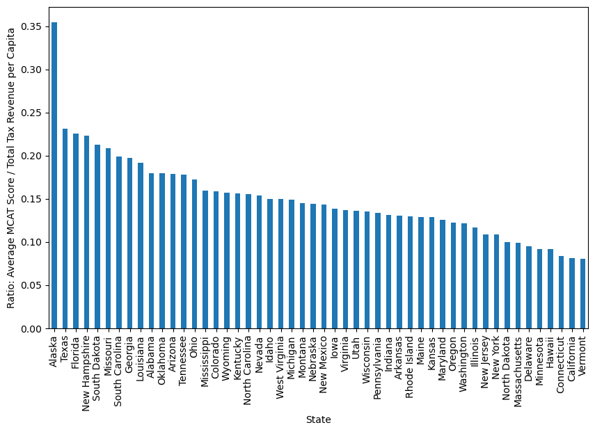

```python
# distribution chart
dfm_vfm_mcat.plot.bar(figsize=(10,6),ylabel="Ratio: Average MCAT Score / Total Tax Revenue per Capita")
```

## What states maximize student-outcome-for-collected-per-capita-tax-dollar, as measured by Average ACT?

```python
dfm_vfm_act = (dfm["Average ACT Score"] / dfm["Total Tax Revenue per Capita"]).sort_values(ascending=False).dropna()
print("* Illinois' rank on ACT value-for-money (= state avg ACT / state per-capita tax revenue) is #{}. Top 10 states:".format(dfm_vfm_act.index.get_loc("Illinois")+1))
dfm_vfm_act.head(10)
```

```
* Illinois' rank on ACT value-for-money (= state avg ACT / state per-capita tax revenue) is #29. Top 10 states:
```

```
State
Alaska            0.013911
New Hampshire     0.010807
South Dakota      0.008747
Texas             0.008581
Florida           0.008392
Missouri          0.008174
Georgia           0.008143
Colorado          0.007721
South Carolina    0.007423
Michigan          0.007006
dtype: float64
```

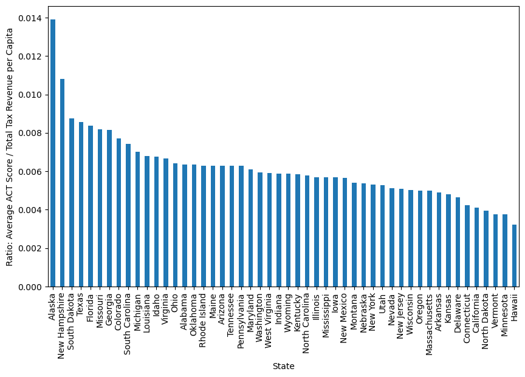

```python
# distribution chart
dfm_vfm_act.plot.bar(figsize=(10,6),ylabel="Ratio: Average ACT Score / Total Tax Revenue per Capita")
```

## What states maximize student-outcome-for-collected-per-capita-tax-dollar, as measured by Average SAT?

```python
dfm_vfm_sat = (dfm["Average SAT Score"] / dfm["Total Tax Revenue per Capita"]).sort_values(ascending=False).dropna()
print("* Illinois' rank on SAT value-for-money (= state avg SAT / state per-capita tax revenue) is #{}. Top 10 states:".format(dfm_vfm_sat.index.get_loc("Illinois")+1))
dfm_vfm_sat.head(10)
```

```
* Illinois' rank on SAT value-for-money (= state avg SAT / state per-capita tax revenue) is #42. Top 10 states:
```

```
State
Alaska           0.752565
South Dakota     0.503182
Missouri         0.486788
Louisiana        0.450437
New Hampshire    0.447428
Texas            0.441716
Florida          0.426661
Tennessee        0.415832
Arizona          0.413490
Alabama          0.410580
dtype: float64
```

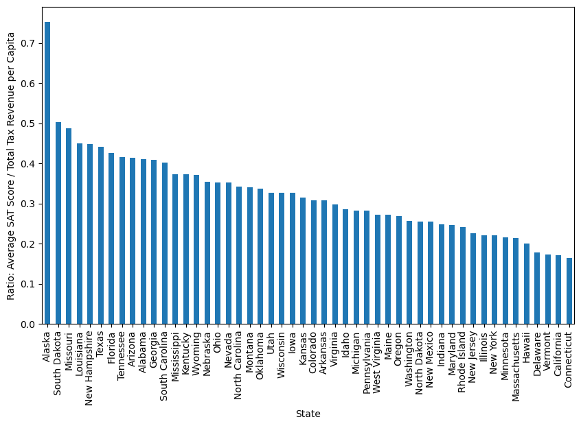

```python
# distribution chart
dfm_vfm_sat.plot.bar(figsize=(10,6),ylabel="Ratio: Average SAT Score / Total Tax Revenue per Capita")
```

## ACT & SAT are HS-matriculation tests for university-bound students. And each state allocates its total tax rake differently; some a greater % to education than others.

### So maybe a fairer comparison is ACT & SAT scores against K-12 spending?

```python
# ACT
dfm_vfm_act = (dfm["Average ACT Score"] / dfm["Public Spending Per K-12 Student"]).sort_values(ascending=False).dropna()
print("* Illinois' rank on ACT value-for-money (= state avg ACT / public expense per K-12 student) is #{}. Top 10 states:".format(dfm_vfm_act.index.get_loc("Illinois")+1))
dfm_vfm_act.head(10)
```

```
* Illinois' rank on ACT value-for-money (= state avg ACT / public expense per K-12 student) is #34. Top 10 states:
```

```
State
Idaho           0.002860
Utah            0.002515
Colorado        0.002258
Indiana         0.002243
Arizona         0.002052
South Dakota    0.002034
Michigan        0.001991
Virginia        0.001978
Oklahoma        0.001957
Mississippi     0.001945
dtype: float64
```

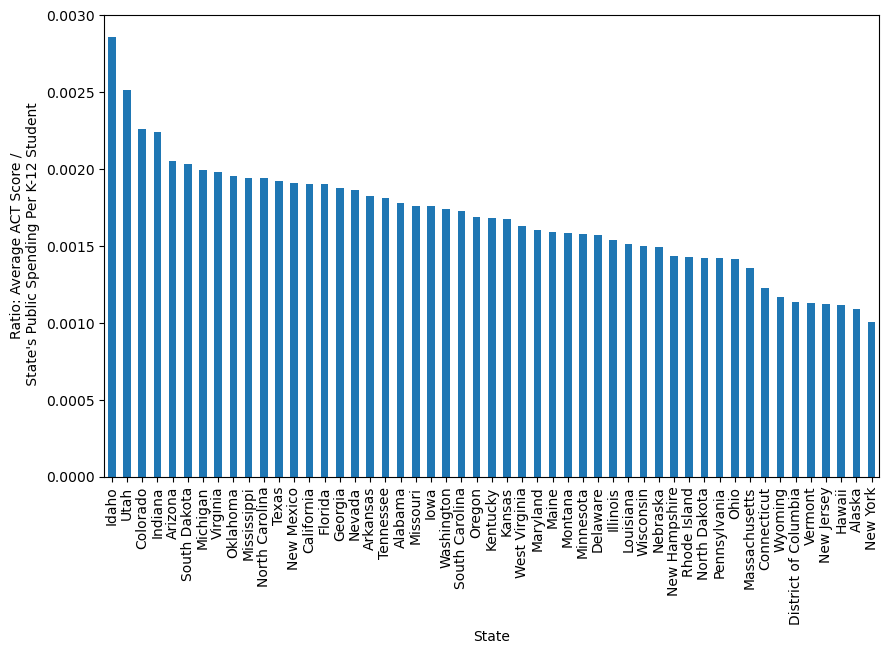

```python
# distribution chart
dfm_vfm_act.plot.bar(figsize=(10,6),ylabel="Ratio: Average ACT Score /\n State's Public Spending Per K-12 Student")
```

```python
# SAT
dfm_vfm_sat = (dfm["Average SAT Score"] / dfm["Public Spending Per K-12 Student"]).sort_values(ascending=False).dropna()
print("* Illinois' rank on SAT value-for-money (= state avg SAT / public expense per K-12 student) is #{}. Top 10 states:".format(dfm_vfm_sat.index.get_loc("Illinois")+1))
dfm_vfm_sat.head(10)
```

```
* Illinois' rank on SAT value-for-money (= state avg SAT / public expense per K-12 student) is #42. Top 10 states:
```

```
State
Utah              0.155829
Arizona           0.134892
Mississippi       0.127931
Nevada            0.127795
Idaho             0.120632
Tennessee         0.119795
South Dakota      0.116986
North Carolina    0.115023
Alabama           0.114860
Arkansas          0.114461
dtype: float64
```

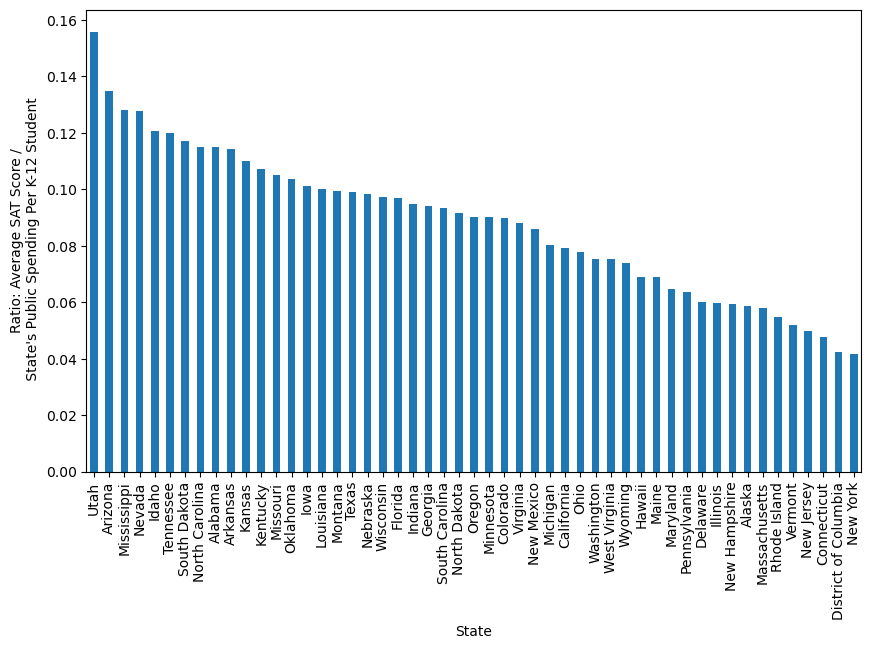

```python
# distribution chart
dfm_vfm_sat.plot.bar(figsize=(10,6),ylabel="Ratio: Average SAT Score /\n State's Public Spending Per K-12 Student")
```

### What about spending as a % of taxpayer income?

```python
# ACT
dfm_vfm_act = (dfm["Average ACT Score"] / dfm["K-12 Spending As Perc Taxpayer Income"]).sort_values(ascending=False).dropna()
print("* Illinois' rank on ACT value-for-money (= state avg ACT / public expense per K-12 student as % of taxpayer income) is #{}. Top 10 states:".format(dfm_vfm_act.index.get_loc("Illinois")+1))
dfm_vfm_act.head(10)
```

```
* Illinois' rank on ACT value-for-money (= state avg ACT / public expense per K-12 student as % of taxpayer income) is #25. Top 10 states:
```

```
State
Colorado                8.802817
California              8.125000
Virginia                7.911392
Washington              7.763975
Idaho                   7.692308
District of Columbia    7.647059
Florida                 7.600000
Massachusetts           7.222222
New Hampshire           7.122507
South Dakota            7.094595
dtype: float64
```

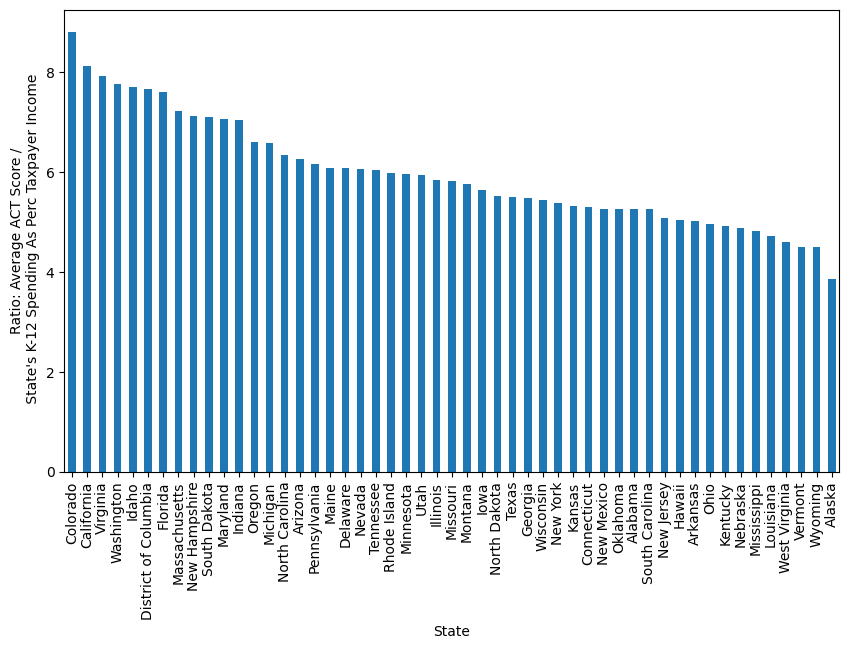

```python
# distribution chart
dfm_vfm_act.plot.bar(figsize=(10,6),ylabel="Ratio: Average ACT Score /\n State's K-12 Spending As Perc Taxpayer Income")
```

```python
# SAT
dfm_vfm_sat = (dfm["Average SAT Score"] / dfm["K-12 Spending As Perc Taxpayer Income"]).sort_values(ascending=False).dropna()
print("* Illinois' rank on SAT value-for-money (= state avg SAT / public expense per K-12 student as % of taxpayer income) is #{}. Top 10 states:".format(dfm_vfm_sat.index.get_loc("Illinois")+1))
dfm_vfm_sat.head(10)
```

```
* Illinois' rank on SAT value-for-money (= state avg SAT / public expense per K-12 student as % of taxpayer income) is #45. Top 10 states:
```

```
State
Nevada            414.946619
Arizona           410.763889
South Dakota      408.108108
Tennessee         399.664430
Florida           386.400000
North Carolina    375.666667
Utah              367.655786
Montana           361.515152
North Dakota      355.524862
Wisconsin         354.154728
dtype: float64
```

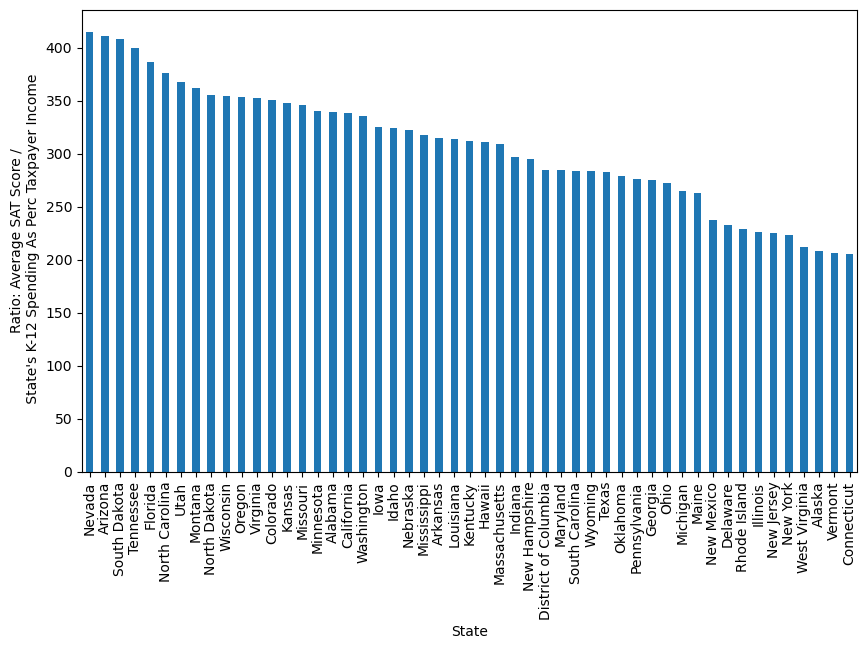

```python
# distribution chart
dfm_vfm_sat.plot.bar(figsize=(10,6),ylabel="Ratio: Average SAT Score /\n State's K-12 Spending As Perc Taxpayer Income")
```

# What about middle-school outcomes?

## Compare grade 8 math % proficiency to per-state K-12 spending.

## What states maximize student-outcome-for-collected-per-capita-tax-dollar, as measured by Grade 8 Math and Public Spending Per K-12 Student?

```python
dfm_vfm_g8math = (dfm["Grade 8 Math % at/above Proficient"] / dfm["Public Spending Per K-12 Student"]).sort_values(ascending=False).dropna()
print("* Illinois' rank on Grade 8 Math value-for-money (= state avg Grade 8 Math / public expense per K-12 student) is #{}. Top 10 states:".format(dfm_vfm_g8math.index.get_loc("Illinois")+1))
dfm_vfm_g8math.head(10)
```

```
* Illinois' rank on Grade 8 Math value-for-money (= state avg Grade 8 Math / public expense per K-12 student) is #36. Top 10 states:
```

```
State
Utah              0.004339
Idaho             0.004033
South Dakota      0.003121
Indiana           0.002936
Arizona           0.002714
Wisconsin         0.002617
North Carolina    0.002590
Colorado          0.002513
Tennessee         0.002492
Virginia          0.002470
dtype: float64
```

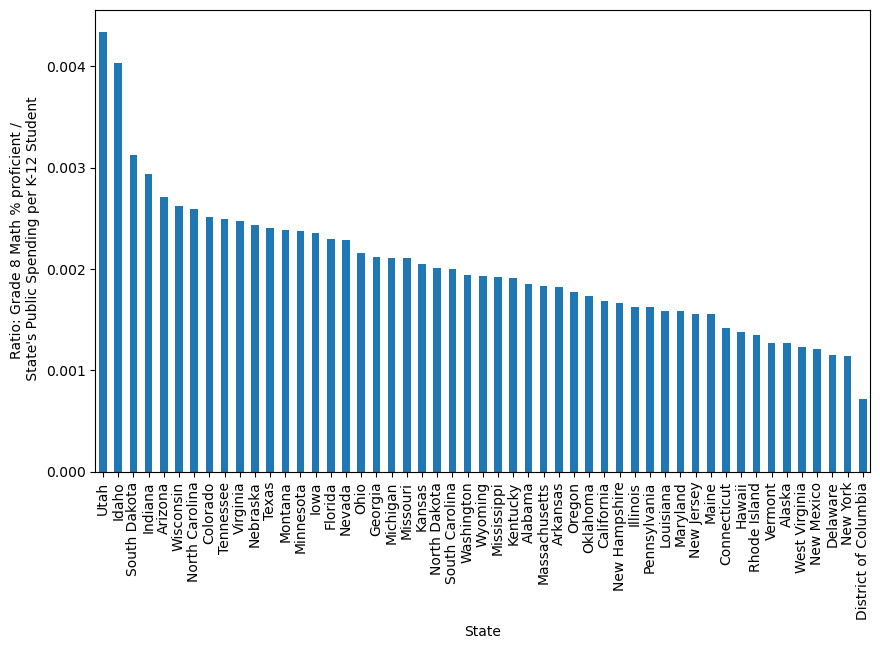

```python
# distribution chart
dfm_vfm_g8math.plot.bar(figsize=(10,6),ylabel="Ratio: Grade 8 Math % proficient /\n State's Public Spending per K-12 Student")
```

## What states maximize student-outcome-for-collected-per-capita-tax-dollar, as measured by Grade 8 Reading and Public Spending Per K-12 Student?

```python
dfm_vfm_g8read = (dfm["Grade 8 Reading % at/above Proficient"] / dfm["Public Spending Per K-12 Student"]).sort_values(ascending=False).dropna()
print("* Illinois' rank on Grade 8 Reading value-for-money (= state avg Grade 8 Reading / public expense per K-12 student) is #{}. Top 10 states:".format(dfm_vfm_g8read.index.get_loc("Illinois")+1))
dfm_vfm_g8read.head(10)
```

```
* Illinois' rank on Grade 8 Reading value-for-money (= state avg Grade 8 Reading / public expense per K-12 student) is #35. Top 10 states:
```

```
State
Utah            0.004485
Idaho           0.003995
Arizona         0.003213
Nevada          0.003157
Colorado        0.003086
South Dakota    0.003014
Indiana         0.002986
Florida         0.002941
Tennessee       0.002820
Georgia         0.002731
dtype: float64
```

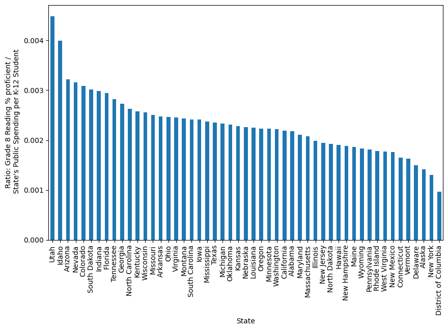

```python
# distribution chart
dfm_vfm_g8read.plot.bar(figsize=(10,6),ylabel="Ratio: Grade 8 Reading % proficient /\n State's Public Spending per K-12 Student")
```

### What about spending as a % of taxpayer income?

```python
dfm_vfm_g8math = (dfm["Grade 8 Math % at/above Proficient"] / dfm["K-12 Spending As Perc Taxpayer Income"]).sort_values(ascending=False).dropna()
print("* Illinois' rank on Grade 8 Math value-for-money (= state avg Grade 8 Math / public expense per K-12 student as % of taxpayer income) is #{}. Top 10 states:".format(dfm_vfm_g8math.index.get_loc("Illinois")+1))
dfm_vfm_g8math.head(10)
```

```
* Illinois' rank on Grade 8 Math value-for-money (= state avg Grade 8 Math / public expense per K-12 student as % of taxpayer income) is #34. Top 10 states:
```

```
State
South Dakota     10.888514
Idaho            10.846154
Utah             10.237389
Virginia          9.876582
Colorado          9.795775
Massachusetts     9.738889
Wisconsin         9.518625
Indiana           9.207951
Florida           9.180000
Minnesota         8.932011
dtype: float64
```

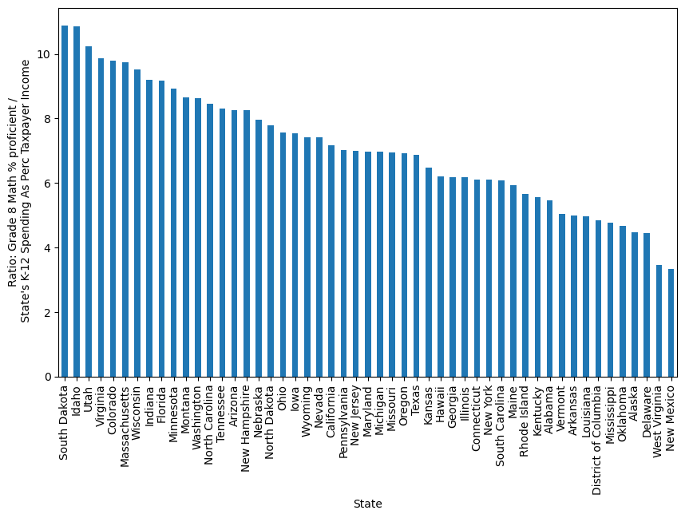

```python
# distribution chart
dfm_vfm_g8math.plot.bar(figsize=(10,6),ylabel="Ratio: Grade 8 Math % proficient /\n State's K-12 Spending As Perc Taxpayer Income")
```

```python
dfm_vfm_g8read = (dfm["Grade 8 Reading % at/above Proficient"] / dfm["K-12 Spending As Perc Taxpayer Income"]).sort_values(ascending=False).dropna()
print("* Illinois' rank on Grade 8 Reading value-for-money (= state avg Grade 8 Reading / public expense per K-12 student as % of taxpayer income) is #{}. Top 10 states:".format(dfm_vfm_g8read.index.get_loc("Illinois")+1))
dfm_vfm_g8read.head(10)
```

```
* Illinois' rank on Grade 8 Reading value-for-money (= state avg Grade 8 Reading / public expense per K-12 student as % of taxpayer income) is #29. Top 10 states:
```

```
State
Colorado         12.028169
Florida          11.744000
Massachusetts    11.055556
Idaho            10.742475
Utah             10.581602
South Dakota     10.513514
Nevada           10.249110
Washington        9.869565
Virginia          9.803797
Arizona           9.784722
dtype: float64
```

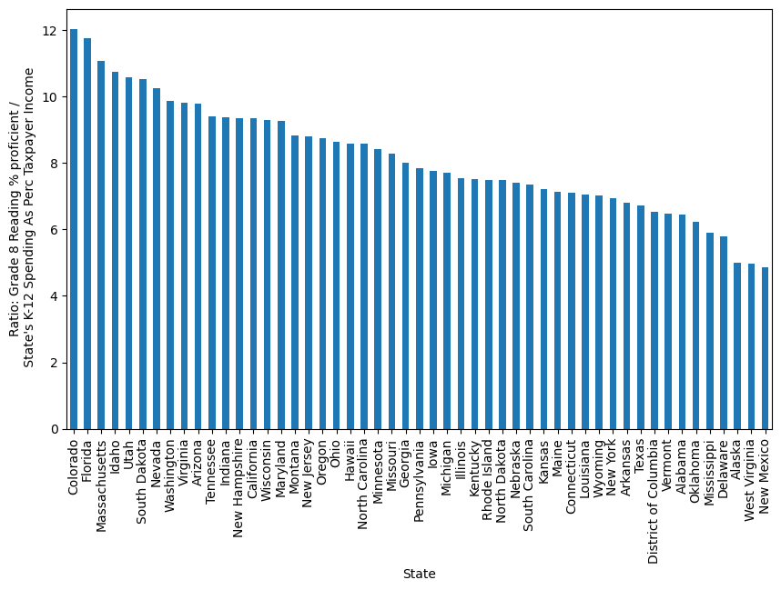

```python
# distribution chart
dfm_vfm_g8read.plot.bar(figsize=(10,6),ylabel="Ratio: Grade 8 Reading % proficient /\n State's K-12 Spending As Perc Taxpayer Income")
```

# What about grade-school outcomes?

## Compare grade 4 math % proficiency to per-state K-12 spending.

## What states maximize student-outcome-for-collected-per-capita-tax-dollar, as measured by Grade 4 Math and Public Spending Per K-12 Student?

```python
dfm_vfm_g8math = (dfm["Grade 4 Math % at/above Proficient"] / dfm["Public Spending Per K-12 Student"]).sort_values(ascending=False).dropna()
print("* Illinois' rank on Grade 4 Math value-for-money (= state avg Grade 4 Math / public expense per K-12 student) is #{}. Top 10 states:".format(dfm_vfm_g8math.index.get_loc("Illinois")+1))
dfm_vfm_g8math.head(10)
```

```
* Illinois' rank on Grade 4 Math value-for-money (= state avg Grade 4 Math / public expense per K-12 student) is #33. Top 10 states:
```

```
State
Utah              0.005292
Idaho             0.004518
Florida           0.004087
South Dakota      0.003901
Texas             0.003863
Indiana           0.003858
Arizona           0.003684
Tennessee         0.003626
North Carolina    0.003613
Mississippi       0.003465
dtype: float64
```

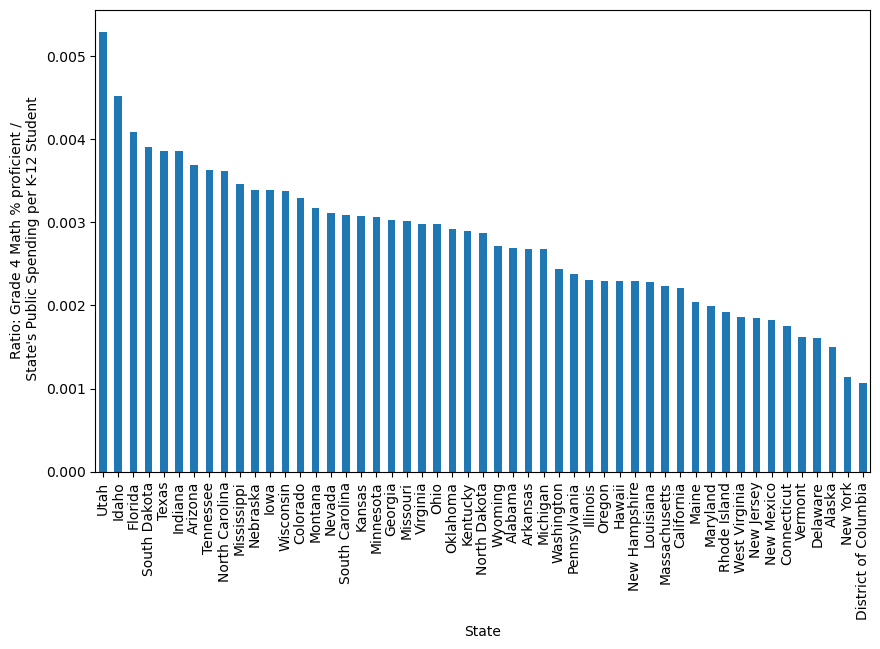

```python
# distribution chart
dfm_vfm_g8math.plot.bar(figsize=(10,6),ylabel="Ratio: Grade 4 Math % proficient /\n State's Public Spending per K-12 Student")
```

## What states maximize student-outcome-for-collected-per-capita-tax-dollar, as measured by Grade 4 Reading and Public Spending Per K-12 Student?

```python
dfm_vfm_g8read = (dfm["Grade 4 Reading % at/above Proficient"] / dfm["Public Spending Per K-12 Student"]).sort_values(ascending=False).dropna()
print("* Illinois' rank on Grade 4 Reading value-for-money (= state avg Grade 4 Reading / public expense per K-12 student) is #{}. Top 10 states:".format(dfm_vfm_g8read.index.get_loc("Illinois")+1))
dfm_vfm_g8read.head(10)
```

```
* Illinois' rank on Grade 4 Reading value-for-money (= state avg Grade 4 Reading / public expense per K-12 student) is #38. Top 10 states:
```

```
State
Utah              0.004632
Idaho             0.003968
Florida           0.003906
Arizona           0.003577
Colorado          0.003396
Mississippi       0.003311
North Carolina    0.003299
Indiana           0.003203
South Dakota      0.003138
Tennessee         0.003035
dtype: float64
```

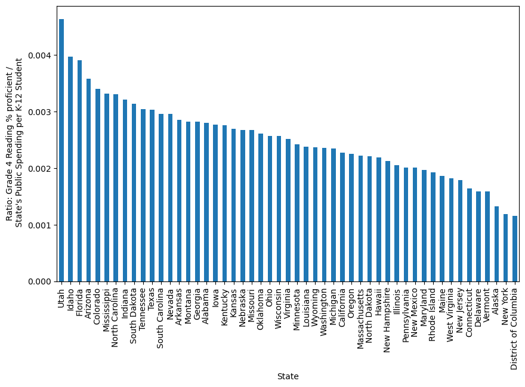

```python
# distribution chart
dfm_vfm_g8read.plot.bar(figsize=(10,6),ylabel="Ratio: Grade 4 Reading % proficient /\n State's Public Spending per K-12 Student")
```

### What about spending as a % of taxpayer income?

```python
dfm_vfm_g8math = (dfm["Grade 4 Math % at/above Proficient"] / dfm["K-12 Spending As Perc Taxpayer Income"]).sort_values(ascending=False).dropna()
print("* Illinois' rank on Grade 4 Math value-for-money (= state avg Grade 4 Math / public expense per K-12 student) is #{}. Top 10 states:".format(dfm_vfm_g8math.index.get_loc("Illinois")+1))
dfm_vfm_g8math.head(10)
```

```
* Illinois' rank on Grade 4 Math value-for-money (= state avg Grade 4 Math / public expense per K-12 student) is #34. Top 10 states:
```

```
State
Florida          16.320000
South Dakota     13.608108
Colorado         12.816901
Utah             12.486647
Wisconsin        12.292264
Idaho            12.150502
Indiana          12.100917
Tennessee        12.097315
Virginia         11.936709
Massachusetts    11.916667
dtype: float64
```

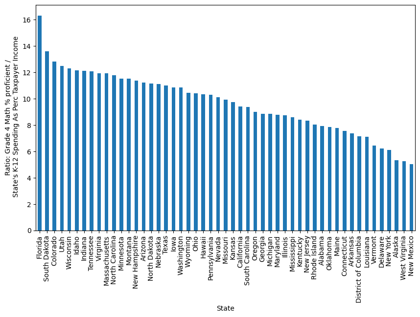

```python
# distribution chart
dfm_vfm_g8math.plot.bar(figsize=(10,6),ylabel="Ratio: Grade 4 Math % proficient /\n State's K-12 Spending As Perc Taxpayer Income")
```

```python
dfm_vfm_g8read = (dfm["Grade 4 Reading % at/above Proficient"] / dfm["K-12 Spending As Perc Taxpayer Income"]).sort_values(ascending=False).dropna()
print("* Illinois' rank on Grade 4 Reading value-for-money (= state avg Grade 4 Reading / public expense per K-12 student) is #{}. Top 10 states:".format(dfm_vfm_g8read.index.get_loc("Illinois")+1))
dfm_vfm_g8read.head(10)
```

```
* Illinois' rank on Grade 4 Reading value-for-money (= state avg Grade 4 Reading / public expense per K-12 student) is #40. Top 10 states:
```

```
State
Florida           15.596000
Colorado          13.235915
Massachusetts     11.836111
South Dakota      10.945946
Utah              10.928783
Arizona           10.892361
North Carolina    10.773333
Idaho             10.672241
New Hampshire     10.547009
Washington        10.472050
dtype: float64
```

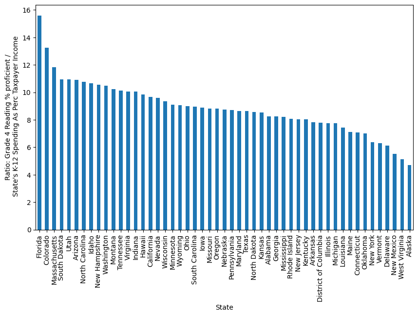

```python
# distribution chart
dfm_vfm_g8read.plot.bar(figsize=(10,6),ylabel="Ratio: Grade 4 Reading % proficient /\n State's K-12 Spending As Perc Taxpayer Income")
```

## Out of curiosity, what is the most-informative feature in the dataset?

```python
from sklearn.feature_selection import SelectKBest, mutual_info_regression

# select the 3 most informative features
kbest = SelectKBest(mutual_info_regression, k=3)
dfm_selected = kbest.fit(
    dfm.dropna()[list(set(dfm.columns)-set(["Grade 8 Math % at/above Proficient"]))],
    dfm.dropna()["Grade 8 Math % at/above Proficient"])
print(dfm_selected.get_feature_names_out())
dfm_selected
```

```
['Rank' 'Grade 4 Reading % at/above Proficient'
 'Grade 4 Math % at/above Proficient']
```

```
SelectKBest(k=3, score_func=<function mutual_info_regression at 0x312b244a0>)
```

```python
# Train a random forest on dfm to predict "Grade 8 Math % at/above Proficient", and in sorted order, print the best features found by the RF.
import pandas as pd
from sklearn.ensemble import RandomForestRegressor
from sklearn.model_selection import train_test_split

# Load the dataset
df = dfm

# Split the dataset into training and testing sets
X = df.dropna()[list(set(df.columns)-set(["Grade 8 Math % at/above Proficient"]))]
y = df.dropna()['Grade 8 Math % at/above Proficient']
X_train, X_test, y_train, y_test = train_test_split(X, y, test_size=0.2, random_state=42)

# Train a random forest regressor on the training set
rf = RandomForestRegressor(n_estimators=10, random_state=42)
rf.fit(X_train, y_train)

# Print the best features found by the RF
pd.DataFrame(zip(rf.feature_names_in_, rf.feature_importances_),columns=["name","importance"]).sort_values(by="importance", ascending=False)
```

|  | name | importance |
| --- | --- | --- |
| 4 | Rank | 0.447083 |
| 12 | Grade 4 Math % at/above Proficient | 0.390906 |
| 2 | Average MCAT Score | 0.038210 |
| 11 | Average SAT Score | 0.018074 |
| 0 | Teachers As A Percent Of Staff Salaries | 0.017093 |
| 1 | Grade 8 Reading % at/above Proficient | 0.015209 |
| 13 | Cost Of Living Index | 0.012941 |
| 5 | Grade 4 Reading % at/above Proficient | 0.012331 |
| 9 | Public Education Average Post Secondary | 0.011876 |
| 7 | Average ACT Score | 0.011308 |
| 6 | K-12 Spending As Perc Taxpayer Income | 0.008660 |
| 8 | Public Funding Per K-12 Student | 0.007186 |
| 3 | Public Spending Per K-12 Student | 0.006086 |
| 10 | Total Tax Revenue per Capita | 0.003038 |

```python
# Same now, but for Grade 8 Reading.
# Split the dataset into training and testing sets
X = df.dropna()[list(set(df.columns)-set(["Grade 8 Reading % at/above Proficient"]))]
y = df.dropna()['Grade 8 Reading % at/above Proficient']
X_train, X_test, y_train, y_test = train_test_split(X, y, test_size=0.2, random_state=42)

# Train a random forest regressor on the training set
rf = RandomForestRegressor(n_estimators=10, random_state=42)
rf.fit(X_train, y_train)

# Print the best features found by the RF
pd.DataFrame(zip(rf.feature_names_in_, rf.feature_importances_),columns=["name","importance"]).sort_values(by="importance", ascending=False)
```

|  | name | importance |
| --- | --- | --- |
| 4 | Rank | 0.490779 |
| 3 | Grade 8 Math % at/above Proficient | 0.128559 |
| 1 | Average MCAT Score | 0.096175 |
| 13 | Cost Of Living Index | 0.079572 |
| 5 | Grade 4 Reading % at/above Proficient | 0.044284 |
| 12 | Grade 4 Math % at/above Proficient | 0.038262 |
| 11 | Average SAT Score | 0.030409 |
| 2 | Public Spending Per K-12 Student | 0.028103 |
| 9 | Public Education Average Post Secondary | 0.023185 |
| 6 | K-12 Spending As Perc Taxpayer Income | 0.020822 |
| 0 | Teachers As A Percent Of Staff Salaries | 0.009750 |
| 10 | Total Tax Revenue per Capita | 0.006303 |
| 8 | Public Funding Per K-12 Student | 0.002601 |
| 7 | Average ACT Score | 0.001194 |

```python
# Same now, but for Average MCAT Score.
# Split the dataset into training and testing sets
X = df.dropna()[list(set(df.columns)-set(["Average MCAT Score"]))]
y = df.dropna()['Average MCAT Score']
X_train, X_test, y_train, y_test = train_test_split(X, y, test_size=0.2, random_state=42)

# Train a random forest regressor on the training set
rf = RandomForestRegressor(n_estimators=10, random_state=42)
rf.fit(X_train, y_train)

# Print the best features found by the RF
pd.DataFrame(zip(rf.feature_names_in_, rf.feature_importances_),columns=["name","importance"]).sort_values(by="importance", ascending=False)
```

|  | name | importance |
| --- | --- | --- |
| 7 | Average ACT Score | 0.445441 |
| 4 | Rank | 0.176914 |
| 1 | Grade 8 Reading % at/above Proficient | 0.086274 |
| 13 | Cost Of Living Index | 0.051691 |
| 9 | Public Education Average Post Secondary | 0.038590 |
| 10 | Total Tax Revenue per Capita | 0.035086 |
| 0 | Teachers As A Percent Of Staff Salaries | 0.033720 |
| 12 | Grade 4 Math % at/above Proficient | 0.032225 |
| 8 | Public Funding Per K-12 Student | 0.029432 |
| 6 | K-12 Spending As Perc Taxpayer Income | 0.023885 |
| 3 | Grade 8 Math % at/above Proficient | 0.017813 |
| 5 | Grade 4 Reading % at/above Proficient | 0.012035 |
| 11 | Average SAT Score | 0.009591 |
| 2 | Public Spending Per K-12 Student | 0.007304 |

```python
# Same now, but for Average ACT Score.
# Split the dataset into training and testing sets
X = df.dropna()[list(set(df.columns)-set(["Average ACT Score"]))]
y = df.dropna()['Average ACT Score']
X_train, X_test, y_train, y_test = train_test_split(X, y, test_size=0.2, random_state=42)

# Train a random forest regressor on the training set
rf = RandomForestRegressor(n_estimators=10, random_state=42)
rf.fit(X_train, y_train)

# Print the best features found by the RF
pd.DataFrame(zip(rf.feature_names_in_, rf.feature_importances_),columns=["name","importance"]).sort_values(by="importance", ascending=False)
```

|  | name | importance |
| --- | --- | --- |
| 2 | Average MCAT Score | 0.462151 |
| 8 | Public Funding Per K-12 Student | 0.132836 |
| 11 | Average SAT Score | 0.116824 |
| 13 | Cost Of Living Index | 0.078146 |
| 5 | Rank | 0.043085 |
| 10 | Total Tax Revenue per Capita | 0.038638 |
| 12 | Grade 4 Math % at/above Proficient | 0.033149 |
| 4 | Grade 8 Math % at/above Proficient | 0.028764 |
| 9 | Public Education Average Post Secondary | 0.025953 |
| 3 | Public Spending Per K-12 Student | 0.015294 |
| 0 | Teachers As A Percent Of Staff Salaries | 0.009143 |
| 1 | Grade 8 Reading % at/above Proficient | 0.007414 |
| 7 | K-12 Spending As Perc Taxpayer Income | 0.004730 |
| 6 | Grade 4 Reading % at/above Proficient | 0.003876 |

```python
# Same now, but for Average SAT Score.
# Split the dataset into training and testing sets
X = df.dropna()[list(set(df.columns)-set(["Average SAT Score"]))]
y = df.dropna()['Average SAT Score']
X_train, X_test, y_train, y_test = train_test_split(X, y, test_size=0.2, random_state=42)

# Train a random forest regressor on the training set
rf = RandomForestRegressor(n_estimators=10, random_state=42)
rf.fit(X_train, y_train)

# Print the best features found by the RF
pd.DataFrame(zip(rf.feature_names_in_, rf.feature_importances_),columns=["name","importance"]).sort_values(by="importance", ascending=False)
```

|  | name | importance |
| --- | --- | --- |
| 8 | Average ACT Score | 0.301801 |
| 4 | Grade 8 Math % at/above Proficient | 0.123751 |
| 1 | Grade 8 Reading % at/above Proficient | 0.091007 |
| 12 | Grade 4 Math % at/above Proficient | 0.087339 |
| 13 | Cost Of Living Index | 0.072585 |
| 10 | Public Education Average Post Secondary | 0.072547 |
| 5 | Rank | 0.057411 |
| 11 | Total Tax Revenue per Capita | 0.051153 |
| 6 | Grade 4 Reading % at/above Proficient | 0.045607 |
| 0 | Teachers As A Percent Of Staff Salaries | 0.044889 |
| 9 | Public Funding Per K-12 Student | 0.019942 |
| 2 | Average MCAT Score | 0.015868 |
| 3 | Public Spending Per K-12 Student | 0.012362 |
| 7 | K-12 Spending As Perc Taxpayer Income | 0.003738 |